# TP Arbres CART

M2 SITIS

Author

Robin Genuer

Published

January 30, 2023

# 1 Données `spam`

Nous considérons dans ces séances de TP le jeu de données `spam` utilisé comme exemple en cours.

Commencer par installer le package `kernlab` qui contient les données `spam` :

```r
install.packages("kernlab")

# à exécuter seulement si le package n'est pas installé
```

Charge les données à l’aide de la commande suivante :

```r
data(spam, package = "kernlab")
```

La commande suivante affiche la strucutre de l’objet `spam` chargé dans l’environnement :

```r
str(spam)
```

Créer un objet `n` contenant le nombre d’individus, et `p` le nombre de variables, grâce à :

```r
n <- nrow(spam)
p <- ncol(spam) - 1
```

Pour un descriptif des données, consulter la page de l’aide grâce à `?kernlab::spam`

**L’objectif est de construire un classifieur capable de prédire le statut du mail (variable appelée `type`) à partir des caractéristiques sur les proportions d’occurences de mots et de caractères dans le mail (les 57 autres variables).**

La fonction `table()` permet d’afficher la répartition de la variable `type` :

```r
table(spam$type)
```

```
nonspam    spam
   2788    1813
```

# 2 Le package `rpart`

Charger le package `rpart` (pour **r**ecursive **part**itioning), puis consulter l’aide de la fonction `rpart` à l’aide de :

```r
library("rpart")
help(rpart)
```

# 3 Construction d’un arbre.

1. Construire un arbre de classification `t_def` à l’aide de la fonction `rpart`, en gardant les valeurs par défaut des différents paramètres. La fonction demande en premier argument une formule du genre $\mathtt{y \sim x}$ et des données `data = spam`. De plus, dans une formule le signe `.` placé à droite du signe $\mathtt{\sim}$ signifie “toutes les variables”.

```r
t_def <- rpart(type ~ ., data=spam)
```

2. Faire afficher l’arbre en tapant `t_def`, tracer l’arbre à l’aide des commandes `plot(t_def)`, puis `text(t_def)`. Consulter également `summary(t_def)`.

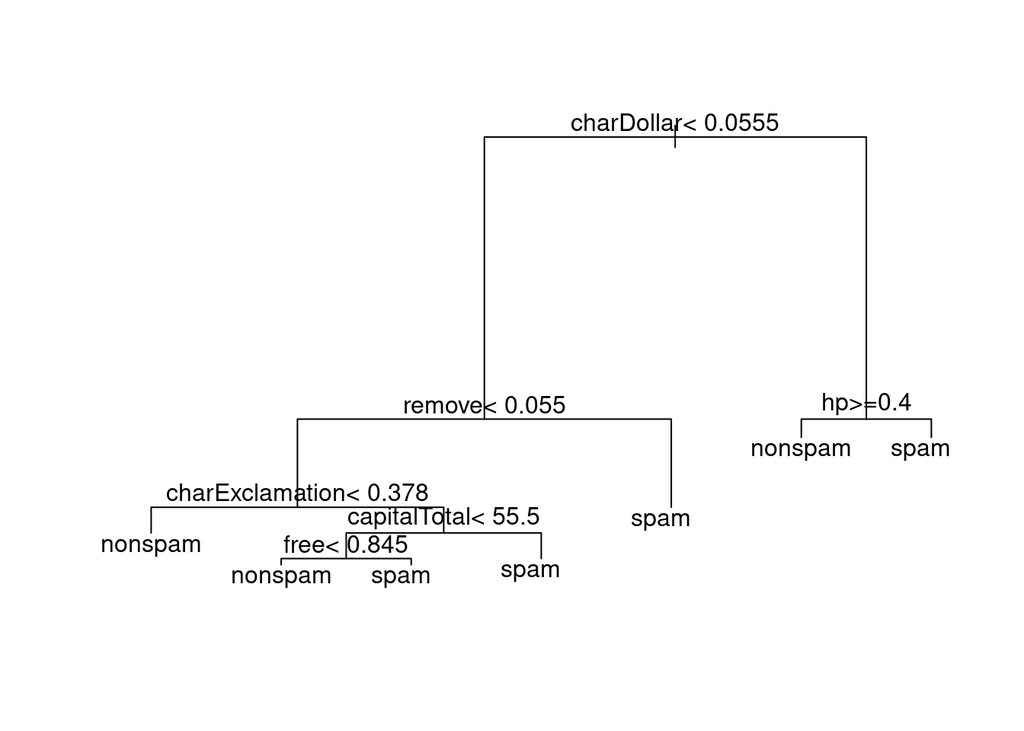

```r
t_def
plot(t_def)
text(t_def, xpd = TRUE)
```

```r
summary(t_def)
```

# 4 Prédictions

Prédire les données de l’échantillon d’apprentissage à l’aide de la fonction `predict`, qui demande comme premier argument le prédicteur par arbre et en deuxième le nom du jeu de données à prédire (regarder l’aide de `predict.rpart`). Calculer alors le taux d’erreur empirique.

```r
pred_t_def <- predict(object = t_def, newdata = spam, type = "class")
err_emp_def <- mean(pred_t_def != spam$type)
err_emp_def
```

```
[1] 0.09737014
```

# 5 Quelques paramètres

Trouver quels arbres sont construits par les commandes suivantes (regarder la fonction `rpart.control` qui permet de régler les paramètres de construction d’un arbre) :

```r
t1 <- rpart(type ~ ., data=spam, maxdepth=1)
t2 <- rpart(type ~ ., data=spam, minsplit=1, cp=0)
```

Faire afficher puis tracer les arbres `t1` et `t2`. Calculer leurs erreurs empiriques.

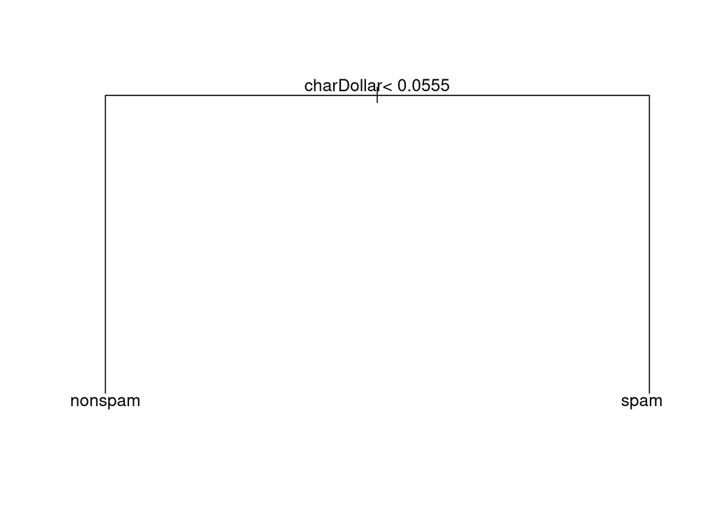

```r
t1
plot(t1);text(t1, xpd = TRUE)
```

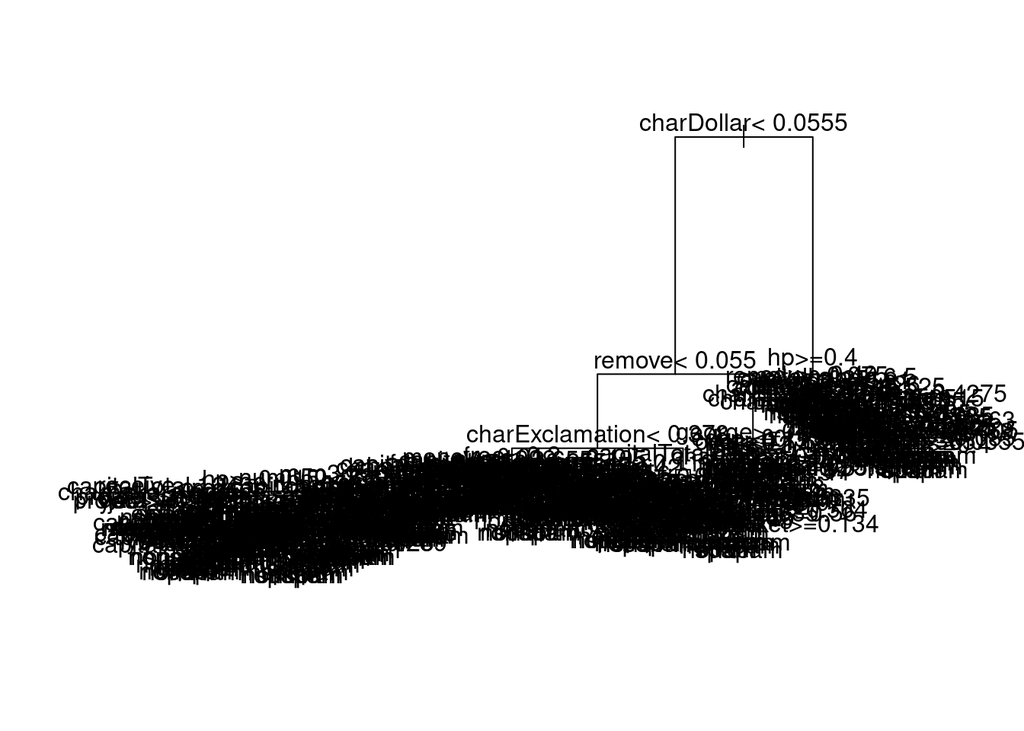

```r
pred_t1 <- predict(t1, spam, type = "class")
err_emp_t1 <- mean(pred_t1 != spam$type)

t2
plot(t2);text(t2, xpd = TRUE)
```

```r
pred_t2 <- predict(t2, spam, type = "class")
err_emp_t2 <- mean(pred_t2 != spam$type)

err_emp <- cbind(err_emp_def, err_emp_t1, err_emp_t2)
```

```r
err_emp
```

```
     err_emp_def err_emp_t1 err_emp_t2
[1,]  0.09737014  0.2062595 0.00108672
```

# 6 Erreur de prédiction

1. Découper aléatoirement le jeu de données en deux. On pourra commencer par utiliser la commande :

   ```r
   sample(1:nrow(spam))
   ```

   qui permet de permuter aléatoirement les indices de lignes du jeu de données `spam`. Il faut alors créer un jeu de données d’entraînement et un jeu de de données de validation.

```r
ind_perm <- sample(1:nrow(spam))
spam_perm <- spam[ind_perm,]
spam_train <- spam_perm[1:(n/2),]
spam_valid <- spam_perm[-(1:(n/2)),]
dim(spam_train)
```

```
[1] 2300   58
```

```r
dim(spam_valid)
```

```
[1] 2301   58
```

2. Calculer des estimations de l’erreur de prédiction pour les 3 arbres construits précédemment.

```r
t_def <- rpart(type ~ ., data=spam_train)
t1 <- rpart(type ~ ., data=spam_train, maxdepth=1)
t2 <- rpart(type ~ ., data=spam_train, minsplit=2, cp=0)

pred_valid_t_def <- predict(t_def, spam_valid, type = "class")
err_valid_t_def <- mean(pred_valid_t_def != spam_valid$type)

pred_valid_t1 <- predict(t1, spam_valid, type = "class")
err_valid_t1 <- mean(pred_valid_t1 != spam_valid$type)

pred_valid_t2 <- predict(t2, spam_valid, type = "class")
err_valid_t2 <- mean(pred_valid_t2 != spam_valid$type)

err_valid <- cbind(err_valid_t_def, err_valid_t1, err_valid_t2)
err_valid
```

```
     err_valid_t_def err_valid_t1 err_valid_t2
[1,]       0.1012603    0.2081704   0.09474142
```

# 7 Elagage.

1. A partir de l’arbre maximal sur le jeu de données d’entraînement, faire afficher les résultats de la construction de la suite de sous-arbres élagués (consulter l’aide de `rpart.object`).

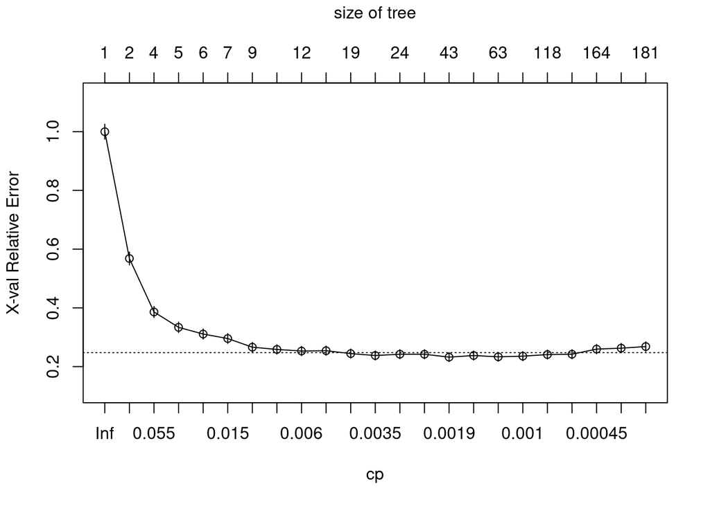

```r
t2$cptable
plotcp(t2)
```

2. Déterminer la valeur de la complexité correspondante au minimum de l’erreur par validation croisée (colonne `xerror`).

```r
ind_cpopt <- which.min(t2$cptable[, 4])
cpopt <- t2$cptable[ind_cpopt, 1]
```

3. Elaguer l’arbre maximal au niveau de cette complexité, en utilisant la fonction `prune`.

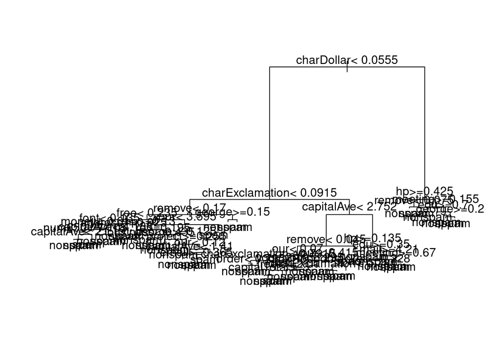

```r
t_opt <- prune(t2, cp = cpopt)
plot(t_opt)
text(t_opt, xpd = TRUE)
```

4. Calculer une estimation de l’erreur de prédiction du meilleur sous-arbre élagué.

```r
pred_valid_t_opt <- predict(t_opt, spam_valid, type = "class")
err_valid_t_opt <- mean(pred_valid_t_opt != spam_valid$type)
err_valid_t_opt
```

```
[1] 0.0751847
```